# Converting from wide to long format & Simple ANOVA in R

Lab Code Challenge 3

Toka

2018-09-25T21:13:14-05:00

## Introduction

In this post, I will discuss about how to convert data from wide format to long format; how to create a 2D figure with information from 3 variables; and how to conduct ANOVA in 3 different ways.

The data in today’s example was collected by our lab (led by Dr. Paul Minda) for the purpose of predicting category-learning on two types of categories (i.e.,RD: Rule-defined, and II: Information Integration). Columns from B to AY are all predictive variables. Columns from AZ to BC are the % correct (i.e., performance) in the 4 blocks of trails from either RD or II. Participants were assigned in either RD or II for all 4 blocks. Column BD is the average performance across the 4 blocks for each participant. We will be taking specific predictive variables as examples to explore their relationship with the outcome variable (i.e., performance)

**Below are the specific instructions we will be following:**

- First, create a new data frame that takes the column with performance in each block (AZ-BC) and puts them into a single column called PERFORMANCE and the a new column called “BLOCK” with 1,2,3,4 as values. This new frame will be four times taller, but does not need to include every variables, only the ones you need.
- Generate a line plot with errorbars (or points) that show PERFORMANCE with BLOCK as X-Axis and different lines for Category. Decide on the best way to also show MONTH (same plot different line, or separate plots)
- Run a mixed factor ANOVA on PERFORMANCE with BLOCK as within and CATEGORY and MONTH and between. You can do the same for CATEGORY and TIME, and even try the full model: PERFORMANCE with BLOCK (within) and CATEGORY, MONTH, and TIME and between.

## Preparation

### Install Packages

```r
#install.packages('prettydoc')
#install.packages('lme4')
#install.packages('ez', dependencies = TRUE)
#install.packages('data.table', dependencies= TRUE)
#install.packages('afex')
```

### Load packages

```r
library(prettydoc)
library(rmarkdown)
library(Rmisc)
library(readxl)
library(ggplot2)
library(data.table)
library(ez)
library(knitr)
library(tidyr)
library(tidyverse)
library(lme4)
```

## Data Manipulation

### Subsetting and Relabelling

Instead of dragging hundreds predictive variables), let’s just pick a few to play with. I selected ‘SubjNum’, ‘Cat’, ‘Month’, ‘DayofWeek’, ‘Time2’ as predictive variables in our new dataframe, and of course, we need performance (i.e., ‘1_Block’, ‘2_Block’, ‘3_Block’, ‘4_Block’, ‘Total’) as our outcome variables.

I renamed some columns so the header row of dataframe is not cramped up together.

```r
data<-read_excel('ModifiedFullData.xlsx')

# Select relevant columns
data<-data[c('SubjNum','Cat','Month','DayofWeek','Time2',
            '1_Block','2_Block','3_Block','4_Block','Total')]

# Rename columns
data<-rename(data,
            Ss=SubjNum,
            Cat=Cat,
            Mon=Month,
            W_day=DayofWeek,
            Time=Time2,
            '1'='1_Block',
            '2'='2_Block',
            '3'='3_Block',
            '4'='4_Block',
            'Total'='Total')

# It's important to convert Subject into factor
# So R doesn't treat the entries as numerics
data$Ss <- factor(data$Ss)

# Drop May data due to incomplete comparison groups
data <- subset(data, Mon != "05_May")

# View head of data
kable(head(data))
```

| Ss | Cat | Mon | W_day | Time | 1 | 2 | 3 | 4 | Total |
| --- | --- | --- | --- | --- | --- | --- | --- | --- | --- |
| 1 | II | 04_Apr | 2_Tue | 1Morning | 0.5750 | 0.7000 | 0.7250 | 0.6000 | 0.6500 |
| 2 | RD | 04_Apr | 2_Tue | 2Early Afternoon | 0.6750 | 0.7000 | 0.7500 | 0.7875 | 0.7281 |
| 3 | II | 04_Apr | 2_Tue | 2Early Afternoon | 0.6375 | 0.6875 | 0.6625 | 0.6500 | 0.6594 |
| 4 | RD | 04_Apr | 2_Tue | 1Morning | 0.6750 | 0.8500 | 0.8000 | 0.8750 | 0.8000 |
| 5 | II | 04_Apr | 3_Wed | 1Morning | 0.5875 | 0.6000 | 0.7375 | 0.7375 | 0.6656 |
| 6 | RD | 04_Apr | 3_Wed | 1Morning | 0.7125 | 0.7500 | 0.7625 | 0.8000 | 0.7563 |

### Changing Data from Wide to Long Form

Here we want to create a new data frame that takes the column with performance in each block (AZ-BC) and puts them into a single column called ‘accuracy’ and the a new column called “block” with 1,2,3,4 as values. This new frame will be four times taller, but does not need to include every variables, only the ones you need.

```r
# Transform data from wide to long form using 'tidyr' package
data_long <- gather(data, block, accuracy, '1':'4',
                    factor_key=TRUE)

# Make sure block is a factor
data_long$block=factor(data_long$block)
kable(head(data_long))
```

| Ss | Cat | Mon | W_day | Time | Total | block | accuracy |
| --- | --- | --- | --- | --- | --- | --- | --- |
| 1 | II | 04_Apr | 2_Tue | 1Morning | 0.6500 | 1 | 0.5750 |
| 2 | RD | 04_Apr | 2_Tue | 2Early Afternoon | 0.7281 | 1 | 0.6750 |
| 3 | II | 04_Apr | 2_Tue | 2Early Afternoon | 0.6594 | 1 | 0.6375 |
| 4 | RD | 04_Apr | 2_Tue | 1Morning | 0.8000 | 1 | 0.6750 |
| 5 | II | 04_Apr | 3_Wed | 1Morning | 0.6656 | 1 | 0.5875 |
| 6 | RD | 04_Apr | 3_Wed | 1Morning | 0.7563 | 1 | 0.7125 |

## Data Visualization

### Plotting performance change across blocks

Generate a line plot with errorbars (or points) that show ‘accuracy’ with ‘block’ as X-Axis and different lines for Category.

First, let’s create a summary table which we would base our graph on.

```r
# Create summary table for block performance on each category type
summary_Block<-summarySE(data_long,
                         measurevar='accuracy',
                         groupvars=c('Cat','block'))

kable(summary_Block)
```

| Cat | block | N | accuracy | sd | se | ci |
| --- | --- | --- | --- | --- | --- | --- |
| II | 1 | 207 | 0.6154589 | 0.0740299 | 0.0051454 | 0.0101445 |
| II | 2 | 207 | 0.6585749 | 0.0922209 | 0.0064098 | 0.0126372 |
| II | 3 | 207 | 0.6783213 | 0.1025849 | 0.0071301 | 0.0140574 |
| II | 4 | 207 | 0.6820235 | 0.1137517 | 0.0079063 | 0.0155876 |
| RD | 1 | 249 | 0.6674711 | 0.1195377 | 0.0075754 | 0.0149203 |
| RD | 2 | 249 | 0.7748494 | 0.1291376 | 0.0081838 | 0.0161185 |
| RD | 3 | 249 | 0.7876004 | 0.1250604 | 0.0079254 | 0.0156096 |
| RD | 4 | 249 | 0.7935137 | 0.1308778 | 0.0082940 | 0.0163357 |

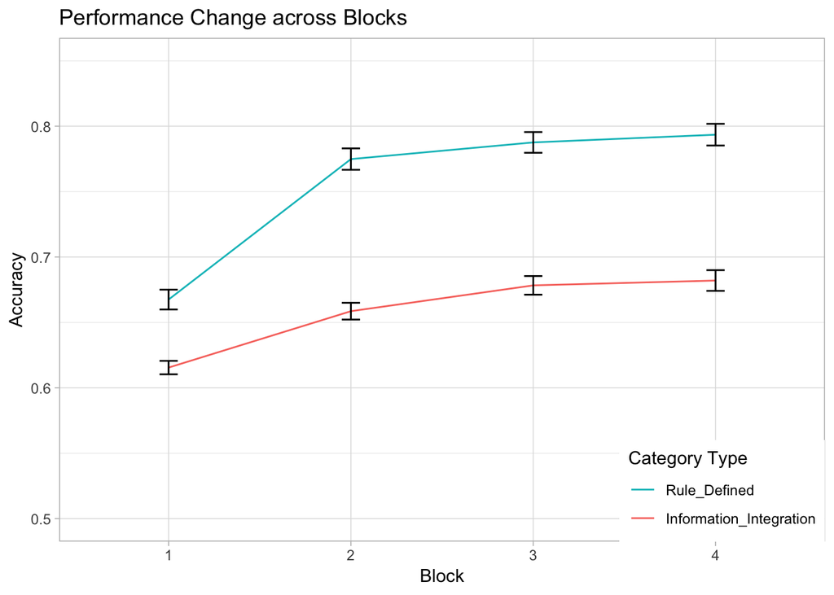

```r
# Plot accuracy change across blocks
ggplot(summary_Block, aes(block, accuracy,
            color= Cat, group= Cat)) +
    geom_line() +

# add errorbar
    geom_errorbar(aes(ymin=accuracy-se, ymax=accuracy+se),
                colour="black", width=.1) +

# add labels and titles
    labs(x= "Block", y= "Accuracy") +
    scale_colour_hue(name="Category Type",
                     breaks=c("RD", "II"),
                     labels=c("Rule_Defined",
                              "Information_Integration")) +
    ggtitle("Performance Change across Blocks") +
    theme(plot.title= element_text(hjust= 0.5)) +

# set range of y
    ylim(.5, .85) +
    theme_light() +

# Position legend in bottom right
    theme(legend.justification=c(1,0),
          legend.position=c(1,0))
```

### Plotting 4 Blocks’ Performance change across the Months

Now, we also want to display MONTH information on our Category-Accuracy figure. First, let’s create a summary table with Month information included.

```r
# Create summary table for plotting accuracy change across months
summary_Month<-summarySE(data_long,
                         measurevar='accuracy',
                         groupvars=c('block','Mon','Cat'))

kable(head(summary_Month))
```

| block | Mon | Cat | N | accuracy | sd | se | ci |
| --- | --- | --- | --- | --- | --- | --- | --- |
| 1 | 01_Jan | II | 39 | 0.6314103 | 0.0799296 | 0.0127990 | 0.0259102 |
| 1 | 01_Jan | RD | 25 | 0.7140000 | 0.1281540 | 0.0256308 | 0.0528994 |
| 1 | 02_Feb | II | 24 | 0.5864583 | 0.0763392 | 0.0155827 | 0.0322352 |
| 1 | 02_Feb | RD | 15 | 0.6627867 | 0.1144415 | 0.0295487 | 0.0633756 |
| 1 | 03_Mar | II | 31 | 0.5850806 | 0.0638536 | 0.0114684 | 0.0234217 |
| 1 | 03_Mar | RD | 33 | 0.6370000 | 0.1245008 | 0.0216728 | 0.0441460 |

There’re many ways to go about creating 2D figure that shows information from 3 variables. I chose to create 2 side-by-side figures seperated by category-type, with Month as x-axis, and accuracy as y-axis, the 4 blocks’ performance are represented in different colors.

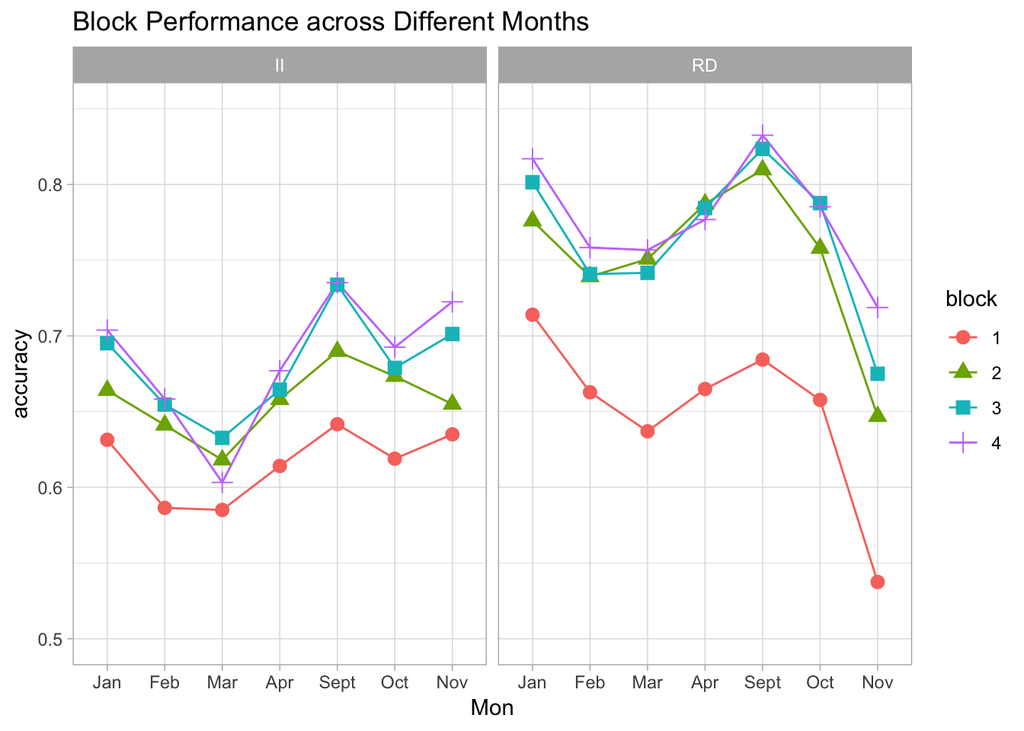

```r
# Plot individual block performance across the months
# Figures are seperated by Category Type
ggplot(summary_Month, aes(Mon, accuracy,
            color= block)) +
    geom_line(aes(group = block)) +
    geom_point(aes(shape = block), size = 3) +
    facet_wrap(~Cat) +
    scale_x_discrete(labels = c("01_Jan" = "Jan", "02_Feb" = "Feb",
                              "03_Mar" = "Mar", "04_Apr" = "Apr",
                              "05_May" = "May", "09_Sep" = "Sept",
                              "10_Oct" = "Oct", "11_Nov" = "Nov"))+

    theme_update(plot.title= element_text(hjust= 0.8)) +
    ggtitle("Block Performance across Different Months") +

# set range of y
    ylim(.5, .85) +
    theme_light()
```

#### Create a summary table of data

I’m creating a summary table to see N for each month because the low RD performance in November looks suspicious to me. We should never interpret a graph without knowing the sample size. Upon inspection of the summary table, we can see that only 4 Ss participated in Nov_RD condition, we now understand this low performance should not be trusted due to the tiny sample size.

```r
summary_data<-summarySE(data,
                         measurevar='Total',
                         groupvars=c('Mon','Cat'))

kable(summary_data)
```

| Mon | Cat | N | Total | sd | se | ci |
| --- | --- | --- | --- | --- | --- | --- |
| 01_Jan | II | 39 | 0.6736429 | 0.0864726 | 0.0138467 | 0.0280312 |
| 01_Jan | RD | 25 | 0.7771440 | 0.1099014 | 0.0219803 | 0.0453651 |
| 02_Feb | II | 24 | 0.6351750 | 0.0635108 | 0.0129641 | 0.0268183 |
| 02_Feb | RD | 15 | 0.7252933 | 0.1395733 | 0.0360377 | 0.0772931 |
| 03_Mar | II | 31 | 0.6097871 | 0.0790917 | 0.0142053 | 0.0290111 |
| 03_Mar | RD | 33 | 0.7215545 | 0.1271817 | 0.0221395 | 0.0450967 |
| 04_Apr | II | 31 | 0.6534290 | 0.0808244 | 0.0145165 | 0.0296466 |
| 04_Apr | RD | 41 | 0.7533683 | 0.1139496 | 0.0177959 | 0.0359669 |
| 09_Sep | II | 27 | 0.7001296 | 0.0557126 | 0.0107219 | 0.0220392 |
| 09_Sep | RD | 68 | 0.7875217 | 0.0850403 | 0.0103127 | 0.0205841 |
| 10_Oct | II | 45 | 0.6659231 | 0.0807144 | 0.0120322 | 0.0242493 |
| 10_Oct | RD | 63 | 0.7410893 | 0.0721438 | 0.0090893 | 0.0181692 |
| 11_Nov | II | 10 | 0.6784375 | 0.0765388 | 0.0242037 | 0.0547525 |
| 11_Nov | RD | 4 | 0.7417468 | 0.0318693 | 0.0159346 | 0.0507111 |

```r
# From this table we can see there were only 4 participants assigned to
# RD category in Nov, therefore, it is too small of a sample size to
# say that people perform worse in Nov.
```

## Mixed ANOVAs

Run a mixed factor ANOVA on ‘accuracy’ with ‘block’ as within and CATEGORY and MONTH and between. You can do the same for CATEGORY and TIME, and even try the full model: ‘accuracy’ with ‘block’ (within) and CATEGORY, MONTH, and TIME and between.

### Using aov function

```r
# mixed ANOVA using aov: with 'block' as within-IV, 'Cat','Month','Time' as between-IV, accuracy is DV
anova1<-aov(accuracy~block*Cat*Mon*Time+
            Error(Ss/block)+(Cat*Mon*Time),
            data=data_long)
summary(anova1)
```

```
##
## Error: Ss
##               Df Sum Sq Mean Sq F value  Pr(>F)
## Cat            1  2.176  2.1761  57.384 2.2e-12 ***
## Mon            6  0.244  0.0406   1.071  0.3821
## Time           2  0.051  0.0253   0.667  0.5145
## Cat:Mon        6  0.225  0.0376   0.990  0.4335
## Cat:Time       2  0.013  0.0067   0.177  0.8377
## Mon:Time      11  0.431  0.0392   1.032  0.4200
## Cat:Mon:Time  10  0.767  0.0767   2.022  0.0338 *
## Residuals    170  6.447  0.0379
## ---
## Signif. codes:  0 '***' 0.001 '**' 0.01 '*' 0.05 '.' 0.1 ' ' 1
##
## Error: Ss:block
##                     Df Sum Sq Mean Sq F value   Pr(>F)
## block                3 2.9068  0.9689 217.913  < 2e-16 ***
## block:Cat            3 0.1833  0.0611  13.740 1.25e-08 ***
## block:Mon           18 0.0670  0.0037   0.837    0.657
## block:Time           6 0.0654  0.0109   2.451    0.024 *
## block:Cat:Mon       18 0.1009  0.0056   1.261    0.208
## block:Cat:Time       6 0.0198  0.0033   0.740    0.617
## block:Mon:Time      33 0.1554  0.0047   1.059    0.382
## block:Cat:Mon:Time  30 0.1606  0.0054   1.204    0.213
## Residuals          510 2.2677  0.0044
## ---
## Signif. codes:  0 '***' 0.001 '**' 0.01 '*' 0.05 '.' 0.1 ' ' 1
##
## Error: Within
##                     Df Sum Sq Mean Sq F value   Pr(>F)
## Cat                  1  2.102  2.1024 176.146  < 2e-16 ***
## Mon                  6  0.950  0.1583  13.260 2.18e-14 ***
## Time                 2  0.047  0.0234   1.962   0.1412
## block:Cat            3  0.131  0.0436   3.653   0.0123 *
## block:Mon           18  0.132  0.0073   0.613   0.8913
## Cat:Mon              6  0.401  0.0668   5.595 1.05e-05 ***
## block:Time           6  0.068  0.0114   0.953   0.4560
## Cat:Time             2  0.092  0.0459   3.849   0.0217 *
## Mon:Time            10  0.266  0.0266   2.229   0.0146 *
## block:Cat:Mon       18  0.087  0.0048   0.406   0.9870
## block:Cat:Time       6  0.007  0.0012   0.103   0.9960
## block:Mon:Time      30  0.129  0.0043   0.360   0.9994
## Cat:Mon:Time        10  0.239  0.0239   2.005   0.0302 *
## block:Cat:Mon:Time  30  0.059  0.0020   0.164   1.0000
## Residuals          840 10.026  0.0119
## ---
## Signif. codes:  0 '***' 0.001 '**' 0.01 '*' 0.05 '.' 0.1 ' ' 1
```

### Using ezANOVA. Returns 1 or more cell with missing data error.

```r
# ezANOVA returns error
# anova2<-ezANOVA(data= data_long,
#                 dv= .(accuracy),
#                 wid= .(Ss),
#                 within= .(block),
#                 between= .(Month, Time, Cat),
#                 type= 3, detailed= TRUE)
```

### Using lme4.

```r
# 'block', 'Cat', 'Month', 'Time' are fixed effects
# 'Ss' is random effects
fullmodel_lmer <- lmer(accuracy ~ block + Cat + Mon + Time +
                       (1|Ss), data_long, REML=FALSE)

# Check how to interpret summary output
summary(fullmodel_lmer)
## Linear mixed model fit by maximum likelihood  ['lmerMod']
## Formula: accuracy ~ block + Cat + Mon + Time + (1 | Ss)
##    Data: data_long
##
##      AIC      BIC   logLik deviance df.resid
##  -3062.4  -2979.8   1546.2  -3092.4     1809
##
## Scaled residuals:
##     Min      1Q  Median      3Q     Max
## -3.4090 -0.4936  0.1313  0.6293  2.7458
##
## Random effects:
##  Groups   Name        Variance Std.Dev.
##  Ss       (Intercept) 0.003629 0.06024
##  Residual             0.009114 0.09547
## Number of obs: 1824, groups:  Ss, 209
##
## Fixed effects:
##                       Estimate Std. Error t value
## (Intercept)           0.619213   0.010263  60.336
## block2                0.078207   0.006322  12.370
## block3                0.094133   0.006322  14.889
## block4                0.099043   0.006322  15.665
## CatRD                 0.091931   0.006053  15.188
## Mon02_Feb            -0.045351   0.011786  -3.848
## Mon03_Mar            -0.064743   0.010423  -6.212
## Mon04_Apr            -0.024326   0.010362  -2.348
## Mon09_Sep             0.015297   0.009968   1.535
## Mon10_Oct            -0.023836   0.008606  -2.770
## Mon11_Nov            -0.039478   0.021244  -1.858
## Time2Early Afternoon -0.010187   0.006666  -1.528
## Time3LateAfternoon    0.005343   0.007804   0.685
```